# Geovis_Lab1

Cho Han

2025-11-02

# 1 Set up the environment

```r
knitr::opts_chunk$set(echo = TRUE)

library(ggplot2)
library(sf)
library(tidyverse)
```

# 2 Import the data

```r
zipcodes <- st_read("/Users/xiaqiuzihan/Downloads/WCZipCodes")
park <- st_read("/Users/xiaqiuzihan/Downloads/Parks_Locations-shp")
st_crs(zipcodes)
```

```
## Coordinate Reference System:
##   User input: NAD83
##   wkt:
## GEOGCRS["NAD83",
##     DATUM["North American Datum 1983",
##         ELLIPSOID["GRS 1980",6378137,298.257222101,
##             LENGTHUNIT["metre",1]]],
##     PRIMEM["Greenwich",0,
##         ANGLEUNIT["degree",0.0174532925199433]],
##     CS[ellipsoidal,2],
##         AXIS["latitude",north,
##             ORDER[1],
##             ANGLEUNIT["degree",0.0174532925199433]],
##         AXIS["longitude",east,
##             ORDER[2],
##             ANGLEUNIT["degree",0.0174532925199433]],
##     ID["EPSG",4269]]
```

```r
st_crs(park) # check two shapefiles' crs and transform to ensure they align
```

```
## Coordinate Reference System:
##   User input: WGS 84 / Pseudo-Mercator
##   wkt:
## PROJCRS["WGS 84 / Pseudo-Mercator",
##     BASEGEOGCRS["WGS 84",
##         ENSEMBLE["World Geodetic System 1984 ensemble",
##             MEMBER["World Geodetic System 1984 (Transit)"],
##             MEMBER["World Geodetic System 1984 (G730)"],
##             MEMBER["World Geodetic System 1984 (G873)"],
##             MEMBER["World Geodetic System 1984 (G1150)"],
##             MEMBER["World Geodetic System 1984 (G1674)"],
##             MEMBER["World Geodetic System 1984 (G1762)"],
##             MEMBER["World Geodetic System 1984 (G2139)"],
##             ELLIPSOID["WGS 84",6378137,298.257223563,
##                 LENGTHUNIT["metre",1]],
##             ENSEMBLEACCURACY[2.0]],
##         PRIMEM["Greenwich",0,
##             ANGLEUNIT["degree",0.0174532925199433]],
##         ID["EPSG",4326]],
##     CONVERSION["Popular Visualisation Pseudo-Mercator",
##         METHOD["Popular Visualisation Pseudo Mercator",
##             ID["EPSG",1024]],
##         PARAMETER["Latitude of natural origin",0,
##             ANGLEUNIT["degree",0.0174532925199433],
##             ID["EPSG",8801]],
##         PARAMETER["Longitude of natural origin",0,
##             ANGLEUNIT["degree",0.0174532925199433],
##             ID["EPSG",8802]],
##         PARAMETER["False easting",0,
##             LENGTHUNIT["metre",1],
##             ID["EPSG",8806]],
##         PARAMETER["False northing",0,
##             LENGTHUNIT["metre",1],
##             ID["EPSG",8807]]],
##     CS[Cartesian,2],
##         AXIS["easting (X)",east,
##             ORDER[1],
##             LENGTHUNIT["metre",1]],
##         AXIS["northing (Y)",north,
##             ORDER[2],
##             LENGTHUNIT["metre",1]],
##     USAGE[
##         SCOPE["Web mapping and visualisation."],
##         AREA["World between 85.06°S and 85.06°N."],
##         BBOX[-85.06,-180,85.06,180]],
##     ID["EPSG",3857]]
```

```r
park <- st_transform(park, 4269) #transform the park shapefile's crs to NAD83 as well
```

From Wayne County, MI ’s GIS data portal, I downloaded the data on the administrative boundaries, in the form of zipcode categorization of the county as my base map, plus shapefiles of locations of county recreation areas for visualization and analysis.

# 3 Geovisualization

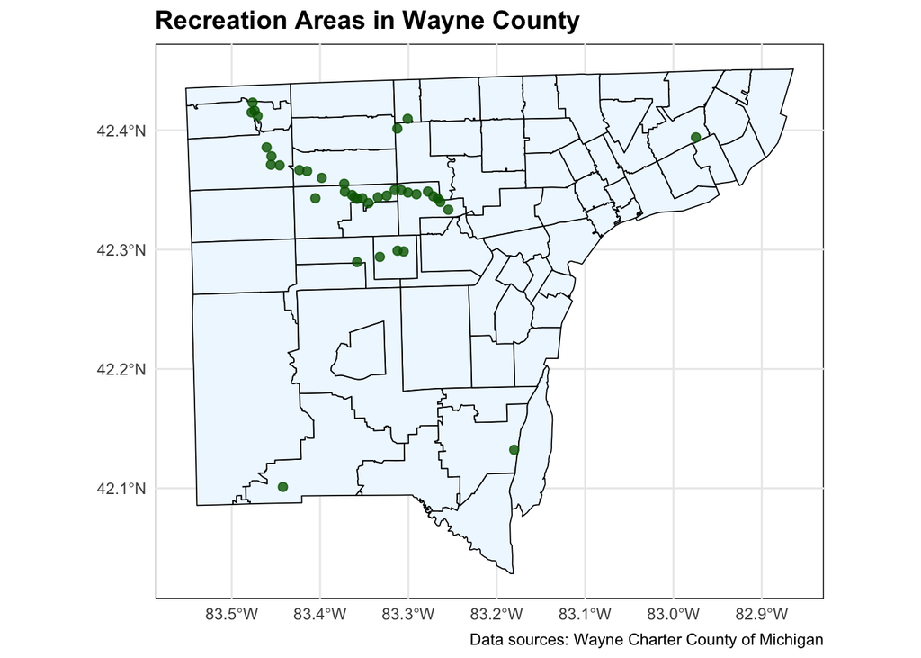

```r
ggplot() +
  geom_sf(data = zipcodes, fill = "aliceblue", color = "black", linewidth = 0.3) +
  geom_sf(data = park, color = "darkgreen", size = 2, alpha = 0.8) +
  labs(
    title = "Recreation Areas in Wayne County",
    caption = "Data sources: Wayne Charter County of Michigan"
  ) +
  theme_minimal() +
  theme(
    panel.background = element_rect(fill = "white"),
    plot.title = element_text(size = 14, face = "bold"),
    plot.subtitle = element_text(size = 12)
  )
```

The above geovisualization shows where all recreation areas/parks are located in Wayne County, MI. I mapped the zipcode shapefile (polygon) as my base map, then adding a point layer of recreation areas on the top of it using ggplot2.

# 4 Descriptive Figures

The recreation area data contain the name of each recreation area, as well as the activities that are allowed in them respectively (e.g., swimming, hiking, fishing).

I wanted to know how many recreation areas in the Wayne county allow for each type of activity respectively through a plot.

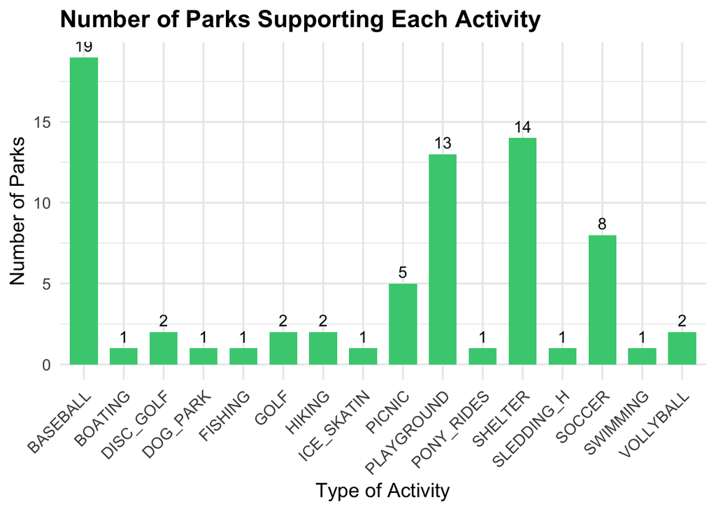

```r
park_df <- park %>%
  st_drop_geometry() #using dataframe format for wrangling

# Convert dataframe to long format
park_long <- park_df %>%
  pivot_longer(
    cols = SWIMMING:DOG_PARK,    # adjust if your last column name differs
    names_to = "activity",
    values_to = "available"
  )

# How many parks allow each activity
activity_df <- park_long %>%
  filter(available == "yes") %>%
  group_by(activity) %>%
  summarise(n_parks = n()) %>%
  arrange(desc(n_parks))

# ploting using ggplot2
ggplot(activity_df, aes(x = activity, y = n_parks)) +
  geom_col(fill = "seagreen3", width = 0.7) +
  geom_text(aes(label = n_parks), vjust = -0.5, size = 4) +
  labs(
    title = "Number of Parks Supporting Each Activity",
    x = "Type of Activity",
    y = "Number of Parks"
  ) +
  theme_minimal(base_size = 14) +
  theme(
    axis.text.x = element_text(angle = 45, hjust = 1), # adjust x-axis categories' height and angel so they won't overlap with the bars.
    plot.title = element_text(face = "bold")
  )
```

# 5 Response to Assignment Questions

Open data science approach allows scholars from different disciplines to collaborate for public knowledge generation, while ensuring the transparency and reproducibility of the research. However, it comes with challenges such as related ethical and privacy concerns, and data might not get recorded consistently or accessibility if no effective data management or version control is applied. This week’s reading provides a good example of the benefits of open data science through merging public perception data into the existing visual schemes for enhanced urban greenspace planning. It details its model and makes its data easily accessible online for future urban planning officials or policy makers’ consideration.